# Kevin Hart Metrics Report

#### Jun 03, 2015

### Goals

| Name | Goal | Achieved |
| --- | --- | --- |
| Media Impressions (Earned) | 250,000,000 | 103,609,876 |
| Media Impressions (Total) | 450,000,000 | 211,874,309 |
| Social Impressions | 10,000,000 | 11,129,498 |
| Email Capture | 1,000,000 | 11,856 |
| Registrations | 500,000 | N/A |

### Summary

- **Weekly Win:** Kevin Hart’s Facebook share of a Rally photo reached over 1.6m people, drove 30,000 likes/comments/shares, and resulted in 150 new page likes.
- **Channel Analysis:** There was an issue with Facebook ad budgeting that caused a temporary drop in email captures. The Edelman team is correcting. Overall, Facebook is still the most cost-effective channel. The average cost-per-registration on Facebook this week was $0.78 (compared to an overall average of $1.1). The average cost-per-registration on Twitter this week was $12.46 (compared to an overall average of $62.47).
- **Targeting:** We’re continuing to target Kevin Hart fans. Waiting for UHC data on Rally eligibility before we ramp up state-specific targeting.
- **Email Campaigns:** The emails continue to do fairly well. Holding off on Email 3 until we get additional assets, which we are pushing for.

### Email Capture

##### Emails Captured to Date: 11,856

#### Email Capture by Channel

Each band of color represents a different acquisition channel. Note: there is a 24-hr lag for this data set

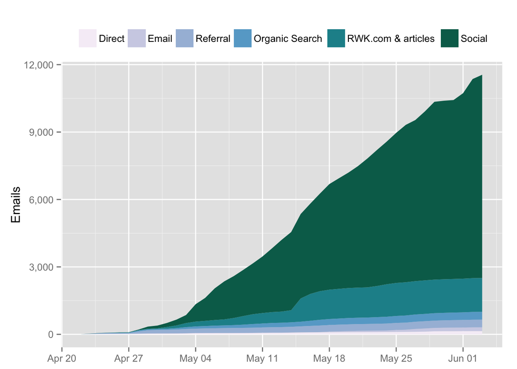

| Channel | Emails |
| --- | --- |
| Social | 9,045 |
| RWK.com & articles | 1,504 |
| Organic Search | 348 |
| Referral | 342 |
| Email | 166 |
| Direct | 145 |

#### Email Capture by State

Darker colors indicate more email captures.

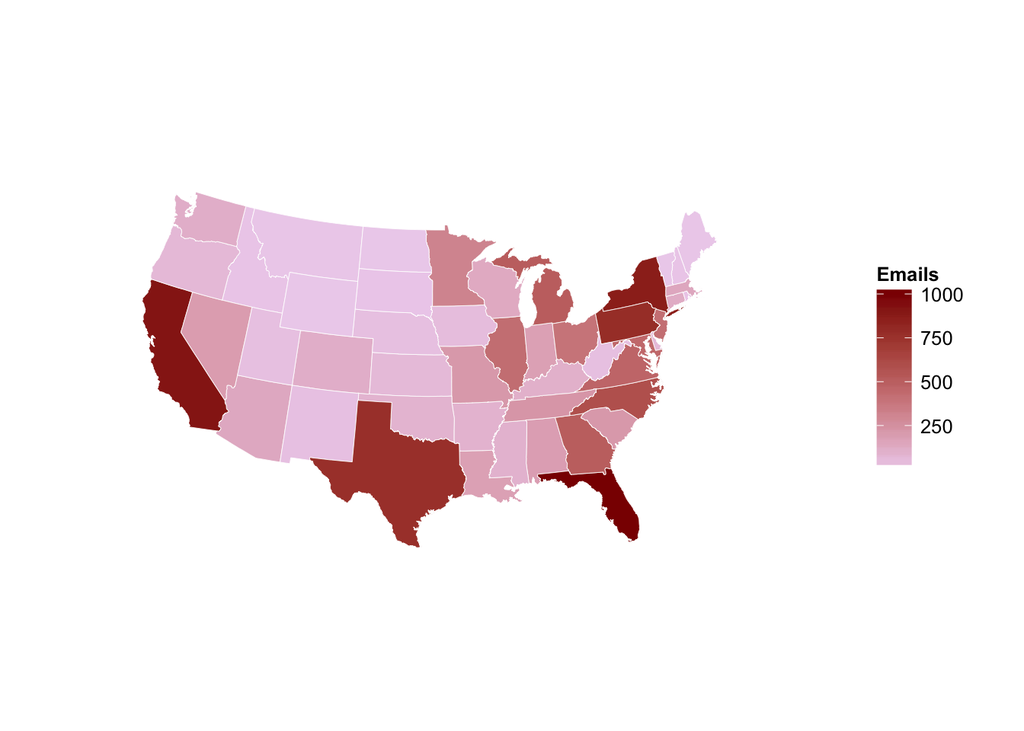

#### Emails Collected by Day (with Trendline)

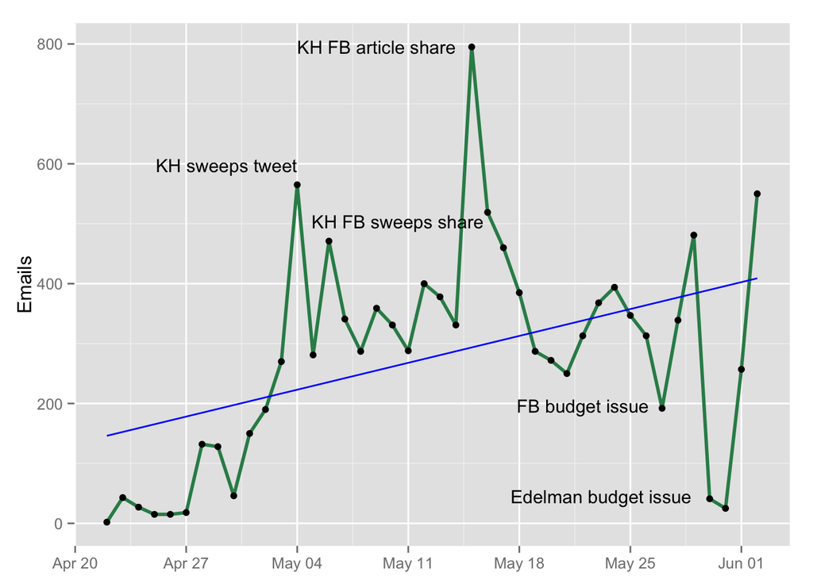

### Email Campaigns

| Email | Open.Rate | CTOR | Total.CTR |
| --- | --- | --- | --- |
| Industry Avg (2014) | 26.20% | 16.70% | 4.80% |
| Welcome | 30.99% | 19.36% | 6.00% |
| KH content | 21.86% | 19.56% | 4.28% |
| TOTAL | 26.43% | 19.46% | 5.14% |

### Media

#### Media Impressions

| Source | Impressions |
| --- | --- |
| Press Release | 103,792,635 |
| Earned Media | 103,609,876 |
| Outbrain (Paid Distribution) | 4,471,798 |
| TOTAL | 211,874,309 |

### Social Metrics

#### Fans/Followers

Growth of Facebook Fans and Twitter Followers.

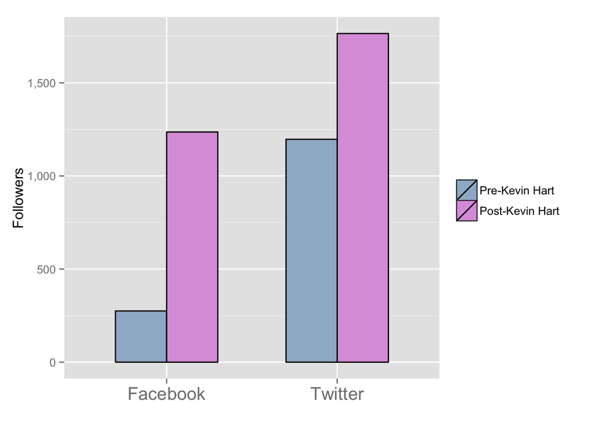

| Network | Pre-Kevin Hart | Post-Kevin Hart | % Change |
| --- | --- | --- | --- |
| Twitter | 1,197 | 1,765 | 47.45 |
| Facebook | 275 | 1,236 | 349.45 |

#### Rally Social Impressions

The number of people who have seen a Rally post or promotion on Twitter or Facebook.

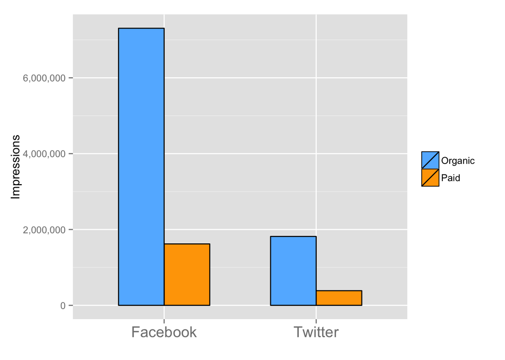

| Channel | Facebook | Twitter | Total |
| --- | --- | --- | --- |
| Paid | 1,619,703 | 386,264 | 2,005,967 |
| Organic | 7,307,163 | 1,816,368 | 9,123,531 |
| Total | 8,926,866 | 2,202,632 | 11,129,498 |

#### Rally Social Engagements

The number of times a user has interacted with a Rally post on Twitter or Facebook.

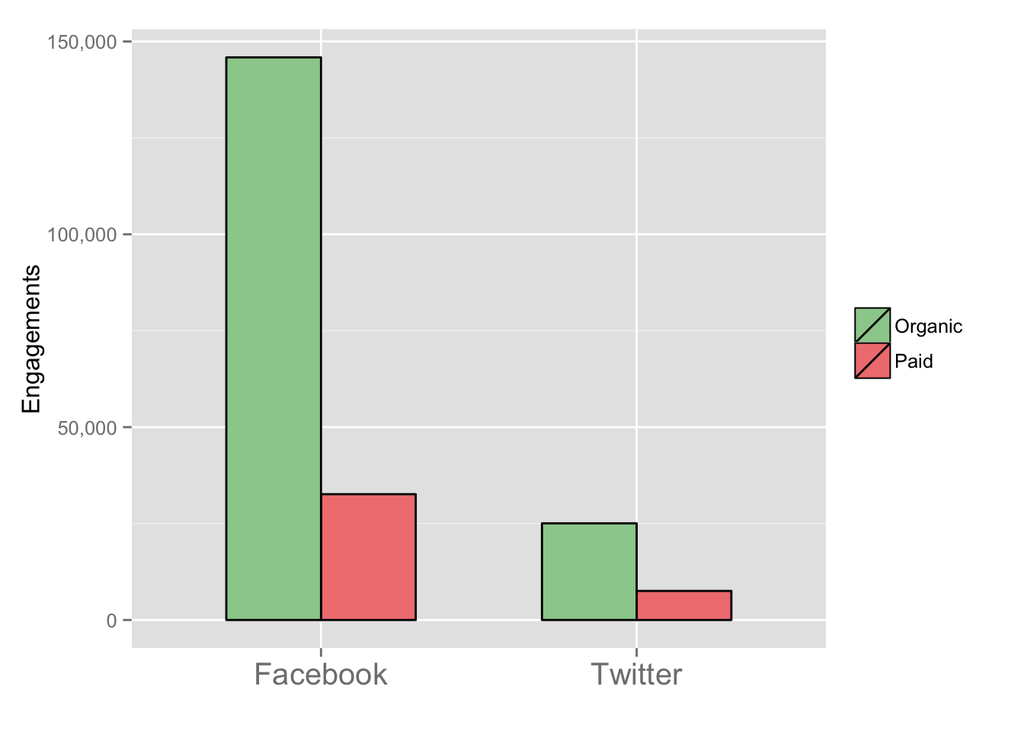

| Channel | Facebook | Twitter | Total |
| --- | --- | --- | --- |
| Paid | 32,618 | 7,533 | 40,151 |
| Organic | 145,881 | 25,067 | 170,948 |
| Total | 178,499 | 32,600 | 211,099 |

#### Overall Cost Per Acquisition

[output not shown]